# Risk Factor Analysis

## Outcome Variable

**Outcome Variable:** haz

## Predictor Variables

**Intervention Variable:** parity

**Adjustment Set:**

- arm
- W_mage
- meducyrs
- feducyrs
- hhwealth_quart
- W_mhtcm
- vagbrth
- W_nrooms
- impsan
- delta_W_mage
- delta_meducyrs
- delta_feducyrs
- delta_hhwealth_quart
- delta_W_mhtcm
- delta_vagbrth
- delta_W_nrooms
- delta_impsan

## Stratifying Variables

The analysis was stratified on these variable(s):

- agecat
- studyid
- country

## Data Summary

| agecat | studyid | country | parity | n_cell | n |
| --- | --- | --- | --- | --- | --- |
| Birth | ki1000304b-SAS-CompFeed | INDIA | 1 | 47 | 187 |
| Birth | ki1000304b-SAS-CompFeed | INDIA | 2 | 53 | 187 |
| Birth | ki1000304b-SAS-CompFeed | INDIA | 3+ | 87 | 187 |
| Birth | ki1101329-Keneba | GAMBIA | 1 | 156 | 1407 |
| Birth | ki1101329-Keneba | GAMBIA | 2 | 146 | 1407 |
| Birth | ki1101329-Keneba | GAMBIA | 3+ | 1105 | 1407 |
| Birth | ki1126311-ZVITAMBO | ZIMBABWE | 1 | 5972 | 13829 |
| Birth | ki1126311-ZVITAMBO | ZIMBABWE | 2 | 4125 | 13829 |
| Birth | ki1126311-ZVITAMBO | ZIMBABWE | 3+ | 3732 | 13829 |
| Birth | ki1135781-COHORTS | GUATEMALA | 1 | 112 | 852 |
| Birth | ki1135781-COHORTS | GUATEMALA | 2 | 137 | 852 |
| Birth | ki1135781-COHORTS | GUATEMALA | 3+ | 603 | 852 |
| Birth | ki1135781-COHORTS | INDIA | 1 | 696 | 4122 |
| Birth | ki1135781-COHORTS | INDIA | 2 | 1037 | 4122 |
| Birth | ki1135781-COHORTS | INDIA | 3+ | 2389 | 4122 |
| Birth | ki1135781-COHORTS | PHILIPPINES | 1 | 675 | 3050 |
| Birth | ki1135781-COHORTS | PHILIPPINES | 2 | 687 | 3050 |
| Birth | ki1135781-COHORTS | PHILIPPINES | 3+ | 1688 | 3050 |
| Birth | kiGH5241-JiVitA-3 | BANGLADESH | 1 | 6271 | 19594 |
| Birth | kiGH5241-JiVitA-3 | BANGLADESH | 2 | 6710 | 19594 |
| Birth | kiGH5241-JiVitA-3 | BANGLADESH | 3+ | 6613 | 19594 |
| 6 months | ki1000304b-SAS-CompFeed | INDIA | 1 | 392 | 1336 |
| 6 months | ki1000304b-SAS-CompFeed | INDIA | 2 | 304 | 1336 |
| 6 months | ki1000304b-SAS-CompFeed | INDIA | 3+ | 640 | 1336 |
| 6 months | ki1000304b-SAS-FoodSuppl | INDIA | 1 | 72 | 373 |
| 6 months | ki1000304b-SAS-FoodSuppl | INDIA | 2 | 84 | 373 |
| 6 months | ki1000304b-SAS-FoodSuppl | INDIA | 3+ | 217 | 373 |
| 6 months | ki1017093b-PROVIDE | BANGLADESH | 1 | 211 | 583 |
| 6 months | ki1017093b-PROVIDE | BANGLADESH | 2 | 212 | 583 |
| 6 months | ki1017093b-PROVIDE | BANGLADESH | 3+ | 160 | 583 |

[output cut: 51 more lines]

The following strata were considered:

- agecat: 24 months, studyid: ki1017093b-PROVIDE, country: BANGLADESH
- agecat: 24 months, studyid: ki1066203-TanzaniaChild2, country: TANZANIA, UNITED REPUBLIC OF
- agecat: 24 months, studyid: ki1101329-Keneba, country: GAMBIA
- agecat: 24 months, studyid: ki1113344-GMS-Nepal, country: NEPAL
- agecat: 24 months, studyid: ki1126311-ZVITAMBO, country: ZIMBABWE
- agecat: 24 months, studyid: ki1135781-COHORTS, country: GUATEMALA
- agecat: 24 months, studyid: ki1135781-COHORTS, country: INDIA
- agecat: 24 months, studyid: ki1135781-COHORTS, country: PHILIPPINES
- agecat: 24 months, studyid: kiGH5241-JiVitA-3, country: BANGLADESH
- agecat: 6 months, studyid: ki1000304b-SAS-CompFeed, country: INDIA
- agecat: 6 months, studyid: ki1000304b-SAS-FoodSuppl, country: INDIA
- agecat: 6 months, studyid: ki1017093b-PROVIDE, country: BANGLADESH
- agecat: 6 months, studyid: ki1066203-TanzaniaChild2, country: TANZANIA, UNITED REPUBLIC OF
- agecat: 6 months, studyid: ki1101329-Keneba, country: GAMBIA
- agecat: 6 months, studyid: ki1113344-GMS-Nepal, country: NEPAL
- agecat: 6 months, studyid: ki1126311-ZVITAMBO, country: ZIMBABWE
- agecat: 6 months, studyid: ki1135781-COHORTS, country: GUATEMALA
- agecat: 6 months, studyid: ki1135781-COHORTS, country: INDIA
- agecat: 6 months, studyid: ki1135781-COHORTS, country: PHILIPPINES
- agecat: 6 months, studyid: kiGH5241-JiVitA-3, country: BANGLADESH
- agecat: Birth, studyid: ki1000304b-SAS-CompFeed, country: INDIA
- agecat: Birth, studyid: ki1101329-Keneba, country: GAMBIA
- agecat: Birth, studyid: ki1126311-ZVITAMBO, country: ZIMBABWE
- agecat: Birth, studyid: ki1135781-COHORTS, country: GUATEMALA
- agecat: Birth, studyid: ki1135781-COHORTS, country: INDIA
- agecat: Birth, studyid: ki1135781-COHORTS, country: PHILIPPINES
- agecat: Birth, studyid: kiGH5241-JiVitA-3, country: BANGLADESH

### Dropped Strata

Some strata were dropped due to rare outcomes:

- agecat: 24 months, studyid: ki1066203-TanzaniaChild2, country: TANZANIA, UNITED REPUBLIC OF

## Methods Detail

We’re interested in the causal parameters $E[Y_a]$ for all values of $a \in \mathcal{A}$. These parameters represent the mean outcome if, possibly contrary to fact, we intervened to set all units to have $A=a$. Under the randomization and positivity assumptions, these are identified by the statistical parameters $\psi_a=E_W[E_{Y|A,W}(Y|A=a,W)]$. In addition, we’re interested in the mean of $Y$, $E[Y]$ under no intervention (the observed mean). We will estimate these parameters by using SuperLearner to fit the relevant likelihood factors – $E_{Y|A,W}(Y|A=a,W)$ and $p(A=a|W)$, and then updating our likelihood fit using a joint TMLE.

For unadjusted analyses ($W=\{\}$), initial likelihoods were estimated using Lrnr_glm to estimate the simple $E(Y|A)$ and Lrnr_mean to estimate $p(A)$. For adjusted analyses, a small library containing Lrnr_glmnet, Lrnr_xgboost, and Lrnr_mean was used.

Having estimated these parameters, we will then use the delta method to estimate relative risks and attributable risks relative to a prespecified baseline level of $A$.

# Results Detail

## Results Plots

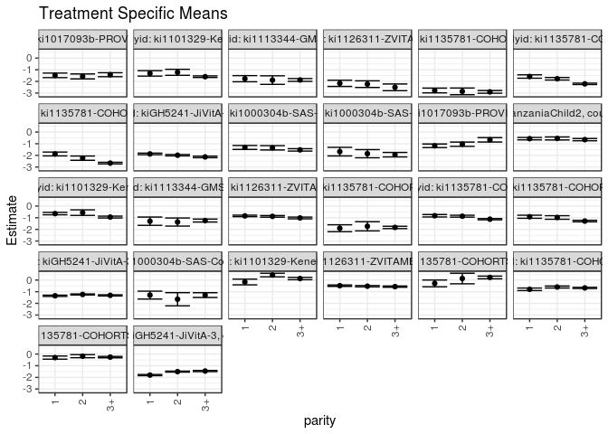

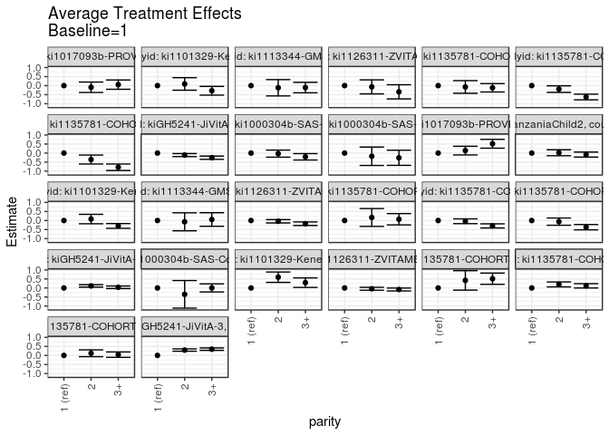

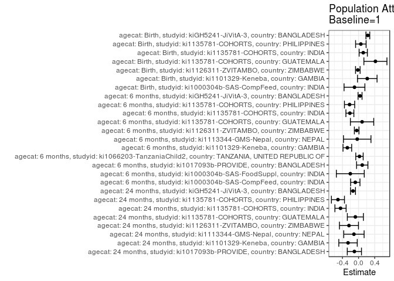

## Results Table

### Parameter: TSM

| agecat | studyid | country | intervention_level | baseline_level | estimate | ci_lower | ci_upper |
| --- | --- | --- | --- | --- | --- | --- | --- |
| Birth | ki1000304b-SAS-CompFeed | INDIA | 1 | NA | -1.2932358 | -1.6324669 | -0.9540047 |
| Birth | ki1000304b-SAS-CompFeed | INDIA | 2 | NA | -1.6445778 | -2.2092033 | -1.0799522 |
| Birth | ki1000304b-SAS-CompFeed | INDIA | 3+ | NA | -1.2898635 | -1.4943805 | -1.0853465 |
| Birth | ki1101329-Keneba | GAMBIA | 1 | NA | -0.1656771 | -0.4104052 | 0.0790510 |
| Birth | ki1101329-Keneba | GAMBIA | 2 | NA | 0.4294019 | 0.2781136 | 0.5806902 |
| Birth | ki1101329-Keneba | GAMBIA | 3+ | NA | 0.1285213 | 0.0281110 | 0.2289317 |
| Birth | ki1126311-ZVITAMBO | ZIMBABWE | 1 | NA | -0.4824481 | -0.5429979 | -0.4218984 |
| Birth | ki1126311-ZVITAMBO | ZIMBABWE | 2 | NA | -0.5264055 | -0.5798889 | -0.4729221 |
| Birth | ki1126311-ZVITAMBO | ZIMBABWE | 3+ | NA | -0.5655655 | -0.6184231 | -0.5127078 |
| Birth | ki1135781-COHORTS | GUATEMALA | 1 | NA | -0.2877454 | -0.5770648 | 0.0015740 |
| Birth | ki1135781-COHORTS | GUATEMALA | 2 | NA | 0.1315278 | -0.3213943 | 0.5844500 |
| Birth | ki1135781-COHORTS | GUATEMALA | 3+ | NA | 0.2242194 | 0.1083484 | 0.3400904 |
| Birth | ki1135781-COHORTS | INDIA | 1 | NA | -0.7935447 | -0.9009071 | -0.6861823 |
| Birth | ki1135781-COHORTS | INDIA | 2 | NA | -0.5972706 | -0.6831521 | -0.5113891 |
| Birth | ki1135781-COHORTS | INDIA | 3+ | NA | -0.6752605 | -0.7274929 | -0.6230280 |
| Birth | ki1135781-COHORTS | PHILIPPINES | 1 | NA | -0.3056068 | -0.4412561 | -0.1699576 |
| Birth | ki1135781-COHORTS | PHILIPPINES | 2 | NA | -0.1848446 | -0.3168504 | -0.0528388 |
| Birth | ki1135781-COHORTS | PHILIPPINES | 3+ | NA | -0.2626257 | -0.3231276 | -0.2021239 |
| Birth | kiGH5241-JiVitA-3 | BANGLADESH | 1 | NA | -1.8050689 | -1.8555856 | -1.7545521 |
| Birth | kiGH5241-JiVitA-3 | BANGLADESH | 2 | NA | -1.5086036 | -1.5516869 | -1.4655203 |
| Birth | kiGH5241-JiVitA-3 | BANGLADESH | 3+ | NA | -1.4581496 | -1.5067448 | -1.4095545 |
| 6 months | ki1000304b-SAS-CompFeed | INDIA | 1 | NA | -1.3204757 | -1.4893295 | -1.1516219 |
| 6 months | ki1000304b-SAS-CompFeed | INDIA | 2 | NA | -1.3513811 | -1.5354890 | -1.1672732 |
| 6 months | ki1000304b-SAS-CompFeed | INDIA | 3+ | NA | -1.5279601 | -1.6308326 | -1.4250876 |
| 6 months | ki1000304b-SAS-FoodSuppl | INDIA | 1 | NA | -1.6782290 | -2.0476123 | -1.3088456 |
| 6 months | ki1000304b-SAS-FoodSuppl | INDIA | 2 | NA | -1.8544711 | -2.2045346 | -1.5044076 |
| 6 months | ki1000304b-SAS-FoodSuppl | INDIA | 3+ | NA | -1.9388459 | -2.1309357 | -1.7467561 |
| 6 months | ki1017093b-PROVIDE | BANGLADESH | 1 | NA | -1.1779386 | -1.3318754 | -1.0240019 |
| 6 months | ki1017093b-PROVIDE | BANGLADESH | 2 | NA | -1.0410817 | -1.2240593 | -0.8581042 |
| 6 months | ki1017093b-PROVIDE | BANGLADESH | 3+ | NA | -0.6640185 | -0.8534138 | -0.4746231 |
| 6 months | ki1066203-TanzaniaChild2 | TANZANIA, UNITED REPUBLIC OF | 1 | NA | -0.5658737 | -0.6677588 | -0.4639886 |
| 6 months | ki1066203-TanzaniaChild2 | TANZANIA, UNITED REPUBLIC OF | 2 | NA | -0.5476572 | -0.6765897 | -0.4187247 |
| 6 months | ki1066203-TanzaniaChild2 | TANZANIA, UNITED REPUBLIC OF | 3+ | NA | -0.6492825 | -0.7451689 | -0.5533960 |
| 6 months | ki1101329-Keneba | GAMBIA | 1 | NA | -0.6457058 | -0.7488984 | -0.5425132 |
| 6 months | ki1101329-Keneba | GAMBIA | 2 | NA | -0.5635273 | -0.8029527 | -0.3241020 |
| 6 months | ki1101329-Keneba | GAMBIA | 3+ | NA | -0.9444349 | -1.0244911 | -0.8643787 |
| 6 months | ki1113344-GMS-Nepal | NEPAL | 1 | NA | -1.2984737 | -1.6530993 | -0.9438481 |
| 6 months | ki1113344-GMS-Nepal | NEPAL | 2 | NA | -1.3696751 | -1.7173969 | -1.0219533 |
| 6 months | ki1113344-GMS-Nepal | NEPAL | 3+ | NA | -1.2426184 | -1.3676860 | -1.1175508 |
| 6 months | ki1126311-ZVITAMBO | ZIMBABWE | 1 | NA | -0.8439147 | -0.9065444 | -0.7812850 |
| 6 months | ki1126311-ZVITAMBO | ZIMBABWE | 2 | NA | -0.8842963 | -0.9535182 | -0.8150744 |
| 6 months | ki1126311-ZVITAMBO | ZIMBABWE | 3+ | NA | -1.0200472 | -1.0955042 | -0.9445902 |
| 6 months | ki1135781-COHORTS | GUATEMALA | 1 | NA | -1.9026447 | -2.1979549 | -1.6073344 |
| 6 months | ki1135781-COHORTS | GUATEMALA | 2 | NA | -1.7360053 | -2.1309762 | -1.3410343 |
| 6 months | ki1135781-COHORTS | GUATEMALA | 3+ | NA | -1.8326187 | -1.9328643 | -1.7323731 |
| 6 months | ki1135781-COHORTS | INDIA | 1 | NA | -0.8304369 | -0.9342340 | -0.7266399 |
| 6 months | ki1135781-COHORTS | INDIA | 2 | NA | -0.8695335 | -0.9522330 | -0.7868340 |
| 6 months | ki1135781-COHORTS | INDIA | 3+ | NA | -1.1264414 | -1.1759851 | -1.0768977 |
| 6 months | ki1135781-COHORTS | PHILIPPINES | 1 | NA | -0.9173624 | -1.0492828 | -0.7854420 |
| 6 months | ki1135781-COHORTS | PHILIPPINES | 2 | NA | -0.9796529 | -1.1312138 | -0.8280921 |
| 6 months | ki1135781-COHORTS | PHILIPPINES | 3+ | NA | -1.2867253 | -1.3512291 | -1.2222215 |
| 6 months | kiGH5241-JiVitA-3 | BANGLADESH | 1 | NA | -1.3497318 | -1.4042546 | -1.2952091 |
| 6 months | kiGH5241-JiVitA-3 | BANGLADESH | 2 | NA | -1.2357770 | -1.2767786 | -1.1947754 |
| 6 months | kiGH5241-JiVitA-3 | BANGLADESH | 3+ | NA | -1.3110191 | -1.3595674 | -1.2624707 |
| 24 months | ki1017093b-PROVIDE | BANGLADESH | 1 | NA | -1.4824025 | -1.6766732 | -1.2881317 |
| 24 months | ki1017093b-PROVIDE | BANGLADESH | 2 | NA | -1.5740063 | -1.7867716 | -1.3612410 |
| 24 months | ki1017093b-PROVIDE | BANGLADESH | 3+ | NA | -1.4267436 | -1.5967537 | -1.2567336 |
| 24 months | ki1101329-Keneba | GAMBIA | 1 | NA | -1.3122678 | -1.5441535 | -1.0803820 |
| 24 months | ki1101329-Keneba | GAMBIA | 2 | NA | -1.2191773 | -1.4781286 | -0.9602260 |
| 24 months | ki1101329-Keneba | GAMBIA | 3+ | NA | -1.5963225 | -1.6660838 | -1.5265612 |
| 24 months | ki1113344-GMS-Nepal | NEPAL | 1 | NA | -1.7686491 | -2.0323265 | -1.5049718 |
| 24 months | ki1113344-GMS-Nepal | NEPAL | 2 | NA | -1.8879864 | -2.2550825 | -1.5208904 |
| 24 months | ki1113344-GMS-Nepal | NEPAL | 3+ | NA | -1.8766414 | -1.9956385 | -1.7576443 |
| 24 months | ki1126311-ZVITAMBO | ZIMBABWE | 1 | NA | -2.1646897 | -2.4316601 | -1.8977192 |
| 24 months | ki1126311-ZVITAMBO | ZIMBABWE | 2 | NA | -2.2339768 | -2.5194302 | -1.9485234 |
| 24 months | ki1126311-ZVITAMBO | ZIMBABWE | 3+ | NA | -2.5080563 | -2.7961720 | -2.2199407 |
| 24 months | ki1135781-COHORTS | GUATEMALA | 1 | NA | -2.7803681 | -2.9826809 | -2.5780552 |
| 24 months | ki1135781-COHORTS | GUATEMALA | 2 | NA | -2.8546206 | -3.1409724 | -2.5682687 |
| 24 months | ki1135781-COHORTS | GUATEMALA | 3+ | NA | -2.8998840 | -3.0153278 | -2.7844402 |
| 24 months | ki1135781-COHORTS | INDIA | 1 | NA | -1.5804398 | -1.7253845 | -1.4354950 |
| 24 months | ki1135781-COHORTS | INDIA | 2 | NA | -1.7726997 | -1.8816805 | -1.6637189 |
| 24 months | ki1135781-COHORTS | INDIA | 3+ | NA | -2.2100528 | -2.2685986 | -2.1515071 |
| 24 months | ki1135781-COHORTS | PHILIPPINES | 1 | NA | -1.8788489 | -2.0450344 | -1.7126634 |
| 24 months | ki1135781-COHORTS | PHILIPPINES | 2 | NA | -2.2365793 | -2.4192401 | -2.0539186 |
| 24 months | ki1135781-COHORTS | PHILIPPINES | 3+ | NA | -2.6629725 | -2.7312877 | -2.5946572 |
| 24 months | kiGH5241-JiVitA-3 | BANGLADESH | 1 | NA | -1.8745293 | -1.9412333 | -1.8078253 |
| 24 months | kiGH5241-JiVitA-3 | BANGLADESH | 2 | NA | -1.9852248 | -2.0431784 | -1.9272712 |
| 24 months | kiGH5241-JiVitA-3 | BANGLADESH | 3+ | NA | -2.1306818 | -2.1974554 | -2.0639082 |

### Parameter: E(Y)

| agecat | studyid | country | intervention_level | baseline_level | estimate | ci_lower | ci_upper |
| --- | --- | --- | --- | --- | --- | --- | --- |
| Birth | ki1000304b-SAS-CompFeed | INDIA | NA | NA | -1.3946524 | -1.5833612 | -1.2059436 |
| Birth | ki1101329-Keneba | GAMBIA | NA | NA | 0.0495949 | -0.0169135 | 0.1161033 |
| Birth | ki1126311-ZVITAMBO | ZIMBABWE | NA | NA | -0.5010160 | -0.5215903 | -0.4804417 |
| Birth | ki1135781-COHORTS | GUATEMALA | NA | NA | 0.1297300 | 0.0458017 | 0.2136584 |
| Birth | ki1135781-COHORTS | INDIA | NA | NA | -0.6773241 | -0.7124609 | -0.6421873 |
| Birth | ki1135781-COHORTS | PHILIPPINES | NA | NA | -0.2490492 | -0.2880580 | -0.2100404 |
| Birth | kiGH5241-JiVitA-3 | BANGLADESH | NA | NA | -1.5749852 | -1.5947616 | -1.5552088 |
| 6 months | ki1000304b-SAS-CompFeed | INDIA | NA | NA | -1.4018563 | -1.4810585 | -1.3226541 |
| 6 months | ki1000304b-SAS-FoodSuppl | INDIA | NA | NA | -1.8829491 | -1.9941876 | -1.7717105 |
| 6 months | ki1017093b-PROVIDE | BANGLADESH | NA | NA | -1.0871041 | -1.1635539 | -1.0106543 |
| 6 months | ki1066203-TanzaniaChild2 | TANZANIA, UNITED REPUBLIC OF | NA | NA | -0.5432778 | -0.5926218 | -0.4939338 |
| 6 months | ki1101329-Keneba | GAMBIA | NA | NA | -0.9239386 | -0.9768148 | -0.8710623 |
| 6 months | ki1113344-GMS-Nepal | NEPAL | NA | NA | -1.3321522 | -1.4103691 | -1.2539352 |
| 6 months | ki1126311-ZVITAMBO | ZIMBABWE | NA | NA | -0.8907964 | -0.9167695 | -0.8648233 |
| 6 months | ki1135781-COHORTS | GUATEMALA | NA | NA | -1.8157336 | -1.8837688 | -1.7476985 |
| 6 months | ki1135781-COHORTS | INDIA | NA | NA | -1.0455022 | -1.0805318 | -1.0104727 |
| 6 months | ki1135781-COHORTS | PHILIPPINES | NA | NA | -1.1405724 | -1.1824954 | -1.0986493 |
| 6 months | kiGH5241-JiVitA-3 | BANGLADESH | NA | NA | -1.3132090 | -1.3363486 | -1.2900693 |
| 24 months | ki1017093b-PROVIDE | BANGLADESH | NA | NA | -1.5861179 | -1.6693668 | -1.5028689 |
| 24 months | ki1101329-Keneba | GAMBIA | NA | NA | -1.5734415 | -1.6295670 | -1.5173160 |
| 24 months | ki1113344-GMS-Nepal | NEPAL | NA | NA | -1.8835905 | -1.9681499 | -1.7990312 |
| 24 months | ki1126311-ZVITAMBO | ZIMBABWE | NA | NA | -2.4026096 | -2.5176913 | -2.2875280 |
| 24 months | ki1135781-COHORTS | GUATEMALA | NA | NA | -2.8597376 | -2.9241330 | -2.7953421 |
| 24 months | ki1135781-COHORTS | INDIA | NA | NA | -2.0277742 | -2.0690209 | -1.9865275 |
| 24 months | ki1135781-COHORTS | PHILIPPINES | NA | NA | -2.3898650 | -2.4346888 | -2.3450412 |
| 24 months | kiGH5241-JiVitA-3 | BANGLADESH | NA | NA | -2.0126333 | -2.0403442 | -1.9849225 |

### Parameter: ATE

| agecat | studyid | country | intervention_level | baseline_level | estimate | ci_lower | ci_upper |
| --- | --- | --- | --- | --- | --- | --- | --- |
| Birth | ki1000304b-SAS-CompFeed | INDIA | 1 | 1 | 0.0000000 | 0.0000000 | 0.0000000 |
| Birth | ki1000304b-SAS-CompFeed | INDIA | 2 | 1 | -0.3513420 | -1.1131252 | 0.4104413 |
| Birth | ki1000304b-SAS-CompFeed | INDIA | 3+ | 1 | 0.0033723 | -0.2209387 | 0.2276833 |
| Birth | ki1101329-Keneba | GAMBIA | 1 | 1 | 0.0000000 | 0.0000000 | 0.0000000 |
| Birth | ki1101329-Keneba | GAMBIA | 2 | 1 | 0.5950790 | 0.3084755 | 0.8816825 |
| Birth | ki1101329-Keneba | GAMBIA | 3+ | 1 | 0.2941984 | 0.0300127 | 0.5583841 |
| Birth | ki1126311-ZVITAMBO | ZIMBABWE | 1 | 1 | 0.0000000 | 0.0000000 | 0.0000000 |
| Birth | ki1126311-ZVITAMBO | ZIMBABWE | 2 | 1 | -0.0439574 | -0.1247257 | 0.0368110 |
| Birth | ki1126311-ZVITAMBO | ZIMBABWE | 3+ | 1 | -0.0831174 | -0.1634517 | -0.0027830 |
| Birth | ki1135781-COHORTS | GUATEMALA | 1 | 1 | 0.0000000 | 0.0000000 | 0.0000000 |
| Birth | ki1135781-COHORTS | GUATEMALA | 2 | 1 | 0.4192732 | -0.1187424 | 0.9572888 |
| Birth | ki1135781-COHORTS | GUATEMALA | 3+ | 1 | 0.5119648 | 0.1998785 | 0.8240511 |
| Birth | ki1135781-COHORTS | INDIA | 1 | 1 | 0.0000000 | 0.0000000 | 0.0000000 |
| Birth | ki1135781-COHORTS | INDIA | 2 | 1 | 0.1962741 | 0.0590714 | 0.3334767 |
| Birth | ki1135781-COHORTS | INDIA | 3+ | 1 | 0.1182842 | -0.0007838 | 0.2373523 |
| Birth | ki1135781-COHORTS | PHILIPPINES | 1 | 1 | 0.0000000 | 0.0000000 | 0.0000000 |
| Birth | ki1135781-COHORTS | PHILIPPINES | 2 | 1 | 0.1207622 | -0.0683252 | 0.3098497 |
| Birth | ki1135781-COHORTS | PHILIPPINES | 3+ | 1 | 0.0429811 | -0.1051898 | 0.1911520 |
| Birth | kiGH5241-JiVitA-3 | BANGLADESH | 1 | 1 | 0.0000000 | 0.0000000 | 0.0000000 |
| Birth | kiGH5241-JiVitA-3 | BANGLADESH | 2 | 1 | 0.2964653 | 0.2315905 | 0.3613400 |
| Birth | kiGH5241-JiVitA-3 | BANGLADESH | 3+ | 1 | 0.3469192 | 0.2798987 | 0.4139397 |
| 6 months | ki1000304b-SAS-CompFeed | INDIA | 1 | 1 | 0.0000000 | 0.0000000 | 0.0000000 |
| 6 months | ki1000304b-SAS-CompFeed | INDIA | 2 | 1 | -0.0309054 | -0.2261387 | 0.1643280 |
| 6 months | ki1000304b-SAS-CompFeed | INDIA | 3+ | 1 | -0.2074844 | -0.3845463 | -0.0304225 |
| 6 months | ki1000304b-SAS-FoodSuppl | INDIA | 1 | 1 | 0.0000000 | 0.0000000 | 0.0000000 |
| 6 months | ki1000304b-SAS-FoodSuppl | INDIA | 2 | 1 | -0.1762421 | -0.6855838 | 0.3330996 |
| 6 months | ki1000304b-SAS-FoodSuppl | INDIA | 3+ | 1 | -0.2606169 | -0.6775776 | 0.1563438 |
| 6 months | ki1017093b-PROVIDE | BANGLADESH | 1 | 1 | 0.0000000 | 0.0000000 | 0.0000000 |
| 6 months | ki1017093b-PROVIDE | BANGLADESH | 2 | 1 | 0.1368569 | -0.1026031 | 0.3763169 |
| 6 months | ki1017093b-PROVIDE | BANGLADESH | 3+ | 1 | 0.5139202 | 0.2699041 | 0.7579362 |
| 6 months | ki1066203-TanzaniaChild2 | TANZANIA, UNITED REPUBLIC OF | 1 | 1 | 0.0000000 | 0.0000000 | 0.0000000 |
| 6 months | ki1066203-TanzaniaChild2 | TANZANIA, UNITED REPUBLIC OF | 2 | 1 | 0.0182165 | -0.1458635 | 0.1822966 |
| 6 months | ki1066203-TanzaniaChild2 | TANZANIA, UNITED REPUBLIC OF | 3+ | 1 | -0.0834087 | -0.2225398 | 0.0557224 |
| 6 months | ki1101329-Keneba | GAMBIA | 1 | 1 | 0.0000000 | 0.0000000 | 0.0000000 |
| 6 months | ki1101329-Keneba | GAMBIA | 2 | 1 | 0.0821785 | -0.1782734 | 0.3426304 |
| 6 months | ki1101329-Keneba | GAMBIA | 3+ | 1 | -0.2987291 | -0.4294746 | -0.1679836 |
| 6 months | ki1113344-GMS-Nepal | NEPAL | 1 | 1 | 0.0000000 | 0.0000000 | 0.0000000 |
| 6 months | ki1113344-GMS-Nepal | NEPAL | 2 | 1 | -0.0712014 | -0.5676976 | 0.4252949 |
| 6 months | ki1113344-GMS-Nepal | NEPAL | 3+ | 1 | 0.0558553 | -0.3199239 | 0.4316346 |
| 6 months | ki1126311-ZVITAMBO | ZIMBABWE | 1 | 1 | 0.0000000 | 0.0000000 | 0.0000000 |
| 6 months | ki1126311-ZVITAMBO | ZIMBABWE | 2 | 1 | -0.0403816 | -0.1335691 | 0.0528058 |
| 6 months | ki1126311-ZVITAMBO | ZIMBABWE | 3+ | 1 | -0.1761325 | -0.2739243 | -0.0783407 |
| 6 months | ki1135781-COHORTS | GUATEMALA | 1 | 1 | 0.0000000 | 0.0000000 | 0.0000000 |
| 6 months | ki1135781-COHORTS | GUATEMALA | 2 | 1 | 0.1666394 | -0.3265668 | 0.6598456 |
| 6 months | ki1135781-COHORTS | GUATEMALA | 3+ | 1 | 0.0700259 | -0.2418220 | 0.3818739 |
| 6 months | ki1135781-COHORTS | INDIA | 1 | 1 | 0.0000000 | 0.0000000 | 0.0000000 |
| 6 months | ki1135781-COHORTS | INDIA | 2 | 1 | -0.0390966 | -0.1710691 | 0.0928759 |
| 6 months | ki1135781-COHORTS | INDIA | 3+ | 1 | -0.2960045 | -0.4104673 | -0.1815417 |
| 6 months | ki1135781-COHORTS | PHILIPPINES | 1 | 1 | 0.0000000 | 0.0000000 | 0.0000000 |
| 6 months | ki1135781-COHORTS | PHILIPPINES | 2 | 1 | -0.0622905 | -0.2623787 | 0.1377977 |
| 6 months | ki1135781-COHORTS | PHILIPPINES | 3+ | 1 | -0.3693629 | -0.5155343 | -0.2231915 |
| 6 months | kiGH5241-JiVitA-3 | BANGLADESH | 1 | 1 | 0.0000000 | 0.0000000 | 0.0000000 |
| 6 months | kiGH5241-JiVitA-3 | BANGLADESH | 2 | 1 | 0.1139548 | 0.0488892 | 0.1790205 |
| 6 months | kiGH5241-JiVitA-3 | BANGLADESH | 3+ | 1 | 0.0387128 | -0.0322709 | 0.1096965 |
| 24 months | ki1017093b-PROVIDE | BANGLADESH | 1 | 1 | 0.0000000 | 0.0000000 | 0.0000000 |
| 24 months | ki1017093b-PROVIDE | BANGLADESH | 2 | 1 | -0.0916039 | -0.3785551 | 0.1953474 |
| 24 months | ki1017093b-PROVIDE | BANGLADESH | 3+ | 1 | 0.0556588 | -0.2023590 | 0.3136767 |
| 24 months | ki1101329-Keneba | GAMBIA | 1 | 1 | 0.0000000 | 0.0000000 | 0.0000000 |
| 24 months | ki1101329-Keneba | GAMBIA | 2 | 1 | 0.0930905 | -0.2535734 | 0.4397543 |
| 24 months | ki1101329-Keneba | GAMBIA | 3+ | 1 | -0.2840547 | -0.5254626 | -0.0426469 |
| 24 months | ki1113344-GMS-Nepal | NEPAL | 1 | 1 | 0.0000000 | 0.0000000 | 0.0000000 |
| 24 months | ki1113344-GMS-Nepal | NEPAL | 2 | 1 | -0.1193373 | -0.5705147 | 0.3318400 |
| 24 months | ki1113344-GMS-Nepal | NEPAL | 3+ | 1 | -0.1079923 | -0.3968296 | 0.1808450 |
| 24 months | ki1126311-ZVITAMBO | ZIMBABWE | 1 | 1 | 0.0000000 | 0.0000000 | 0.0000000 |
| 24 months | ki1126311-ZVITAMBO | ZIMBABWE | 2 | 1 | -0.0692871 | -0.4570101 | 0.3184358 |
| 24 months | ki1126311-ZVITAMBO | ZIMBABWE | 3+ | 1 | -0.3433666 | -0.7350169 | 0.0482836 |
| 24 months | ki1135781-COHORTS | GUATEMALA | 1 | 1 | 0.0000000 | 0.0000000 | 0.0000000 |
| 24 months | ki1135781-COHORTS | GUATEMALA | 2 | 1 | -0.0742525 | -0.4244435 | 0.2759385 |
| 24 months | ki1135781-COHORTS | GUATEMALA | 3+ | 1 | -0.1195159 | -0.3522353 | 0.1132034 |
| 24 months | ki1135781-COHORTS | INDIA | 1 | 1 | 0.0000000 | 0.0000000 | 0.0000000 |
| 24 months | ki1135781-COHORTS | INDIA | 2 | 1 | -0.1922599 | -0.3735986 | -0.0109212 |
| 24 months | ki1135781-COHORTS | INDIA | 3+ | 1 | -0.6296130 | -0.7858896 | -0.4733365 |
| 24 months | ki1135781-COHORTS | PHILIPPINES | 1 | 1 | 0.0000000 | 0.0000000 | 0.0000000 |
| 24 months | ki1135781-COHORTS | PHILIPPINES | 2 | 1 | -0.3577305 | -0.6042656 | -0.1111953 |
| 24 months | ki1135781-COHORTS | PHILIPPINES | 3+ | 1 | -0.7841236 | -0.9636135 | -0.6046337 |
| 24 months | kiGH5241-JiVitA-3 | BANGLADESH | 1 | 1 | 0.0000000 | 0.0000000 | 0.0000000 |
| 24 months | kiGH5241-JiVitA-3 | BANGLADESH | 2 | 1 | -0.1106955 | -0.1935476 | -0.0278433 |
| 24 months | kiGH5241-JiVitA-3 | BANGLADESH | 3+ | 1 | -0.2561525 | -0.3469320 | -0.1653729 |

### Parameter: PAR

| agecat | studyid | country | intervention_level | baseline_level | estimate | ci_lower | ci_upper |
| --- | --- | --- | --- | --- | --- | --- | --- |
| Birth | ki1000304b-SAS-CompFeed | INDIA | 1 | NA | -0.1014166 | -0.3595689 | 0.1567356 |
| Birth | ki1101329-Keneba | GAMBIA | 1 | NA | 0.2152720 | -0.0275796 | 0.4581235 |
| Birth | ki1126311-ZVITAMBO | ZIMBABWE | 1 | NA | -0.0185678 | -0.0749545 | 0.0378188 |
| Birth | ki1135781-COHORTS | GUATEMALA | 1 | NA | 0.4174754 | 0.1318177 | 0.7031331 |
| Birth | ki1135781-COHORTS | INDIA | 1 | NA | 0.1162206 | 0.0141993 | 0.2182418 |
| Birth | ki1135781-COHORTS | PHILIPPINES | 1 | NA | 0.0565576 | -0.0735233 | 0.1866386 |
| Birth | kiGH5241-JiVitA-3 | BANGLADESH | 1 | NA | 0.2300837 | 0.1827872 | 0.2773801 |
| 6 months | ki1000304b-SAS-CompFeed | INDIA | 1 | NA | -0.0813806 | -0.1971767 | 0.0344155 |
| 6 months | ki1000304b-SAS-FoodSuppl | INDIA | 1 | NA | -0.2047201 | -0.5504971 | 0.1410569 |
| 6 months | ki1017093b-PROVIDE | BANGLADESH | 1 | NA | 0.0908346 | -0.0497169 | 0.2313860 |
| 6 months | ki1066203-TanzaniaChild2 | TANZANIA, UNITED REPUBLIC OF | 1 | NA | 0.0225960 | -0.0691971 | 0.1143890 |
| 6 months | ki1101329-Keneba | GAMBIA | 1 | NA | -0.2782327 | -0.3855956 | -0.1708699 |
| 6 months | ki1113344-GMS-Nepal | NEPAL | 1 | NA | -0.0336784 | -0.3744101 | 0.3070532 |
| 6 months | ki1126311-ZVITAMBO | ZIMBABWE | 1 | NA | -0.0468817 | -0.1040970 | 0.0103337 |
| 6 months | ki1135781-COHORTS | GUATEMALA | 1 | NA | 0.0869111 | -0.2022375 | 0.3760597 |
| 6 months | ki1135781-COHORTS | INDIA | 1 | NA | -0.2150653 | -0.3137228 | -0.1164078 |
| 6 months | ki1135781-COHORTS | PHILIPPINES | 1 | NA | -0.2232099 | -0.3502861 | -0.0961337 |
| 6 months | kiGH5241-JiVitA-3 | BANGLADESH | 1 | NA | 0.0365229 | -0.0132165 | 0.0862623 |
| 24 months | ki1017093b-PROVIDE | BANGLADESH | 1 | NA | -0.1037154 | -0.2797308 | 0.0723000 |
| 24 months | ki1101329-Keneba | GAMBIA | 1 | NA | -0.2611737 | -0.4897684 | -0.0325790 |
| 24 months | ki1113344-GMS-Nepal | NEPAL | 1 | NA | -0.1149414 | -0.3674573 | 0.1375745 |
| 24 months | ki1126311-ZVITAMBO | ZIMBABWE | 1 | NA | -0.2379200 | -0.4737437 | -0.0020962 |
| 24 months | ki1135781-COHORTS | GUATEMALA | 1 | NA | -0.0793695 | -0.2782879 | 0.1195489 |
| 24 months | ki1135781-COHORTS | INDIA | 1 | NA | -0.4473344 | -0.5863122 | -0.3083566 |
| 24 months | ki1135781-COHORTS | PHILIPPINES | 1 | NA | -0.5110162 | -0.6726331 | -0.3493992 |
| 24 months | kiGH5241-JiVitA-3 | BANGLADESH | 1 | NA | -0.1381040 | -0.1998042 | -0.0764038 |